# Colgate vs Crest

Sara Bengoechea Rodríguez

## Introducción

En el presente informe se busca predecir las ventas para 16 semanas del año 1963 de las empresas de pasta dentífrica Colgate y Crest. Así mismo, se estudia cómo influyó en las series temporales de los rendimientos de dichas empresas, el lanzamiento de un anuncio del Consejo de Terapéutica Dental de la American Dental Association (ADA).

## Análisis Exploratorio de los datos

En el gráfico siguiente se muestra la evolución de la participación de Colgate y Crest, marcando con una línea en rojo la fecha en la que el Consejo de Terapéutica Dental de la American Dental Association (ADA) lanzó el anuncio que que en el que aprobaba a Crest como “ayuda importante en cualquier programa de higiene dental”.

Como se puede observar, ninguna de las dos es una serie estacionaria ya que su media y varianza no son constantes.

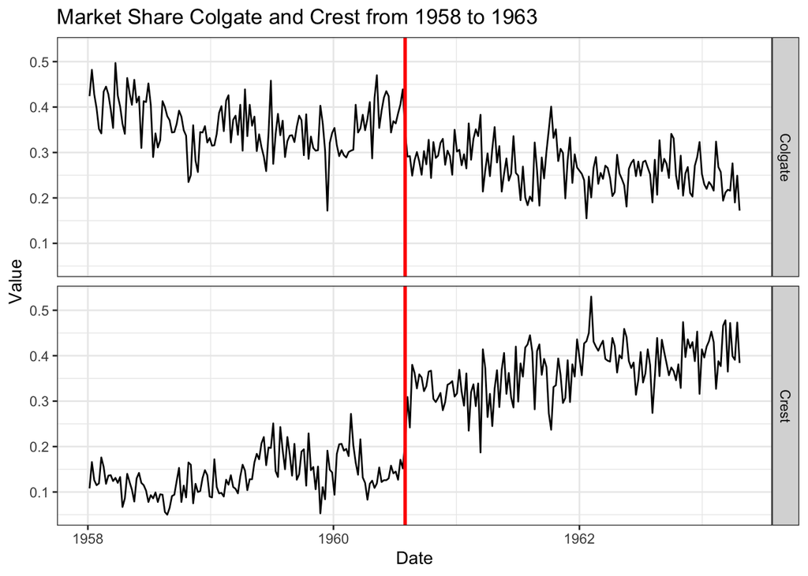

## Modelo Arima

El mejor modelo ARIMA de tanto de Crest como de Colgate es 0,1,1. El 0 significa que no tiene autoregresivos, el 1 son las diferencias necesarias para ser estacionaria y el último 1 pertenece a la media móvil.

```
## Series: trainCrest
## ARIMA(0,1,1)
##
## Coefficients:
##           ma1
##       -0.6494
## s.e.   0.0447
##
## sigma^2 estimated as 0.002046:  log likelihood=436.25
## AIC=-868.51   AICc=-868.46   BIC=-861.38
##
## Training set error measures:
##                       ME       RMSE        MAE       MPE     MAPE      MASE
## Training set 0.003007244 0.04505787 0.03432215 -2.913157 17.20469 0.1396754
##                     ACF1
## Training set -0.04618293
```

```
## Series: trainColgate
## ARIMA(0,1,1)
##
## Coefficients:
##           ma1
##       -0.7600
## s.e.   0.0463
##
## sigma^2 estimated as 0.002309:  log likelihood=420.38
## AIC=-836.76   AICc=-836.71   BIC=-829.64
##
## Training set error measures:
##                        ME       RMSE        MAE       MPE     MAPE      MASE
## Training set -0.002752692 0.04786537 0.03775483 -3.107405 12.80497 0.1189681
##                    ACF1
## Training set 0.05403327
```

Mediante los correlogramas ACF y PACF podemos estudiar la estacionalidad de las series. Como se puede ver, en escasos momentos podemos ver que sobrepasa la línea discontinua azul, lo que significa que no sería estacional.

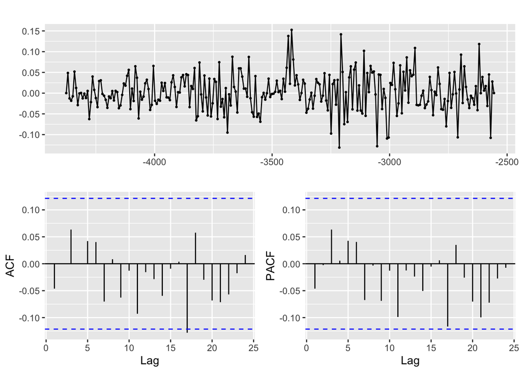

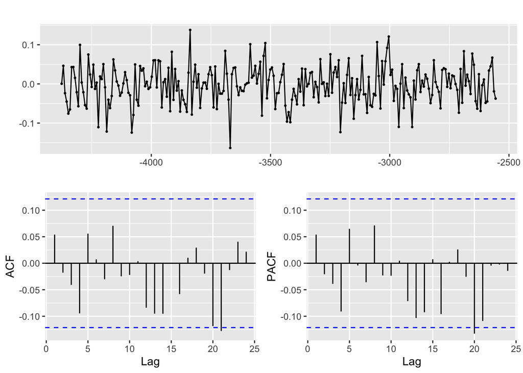

```
##
##  Box-Ljung test
##
## data:  Crest.arima$residuals
## X-squared = 13.303, df = 16, p-value = 0.6505
```

```
##
##  Box-Ljung test
##
## data:  Colgate.arima$residuals
## X-squared = 14.381, df = 16, p-value = 0.5704
```

## Detección de Outliers

A continuación identificamos los outliers aditivos (que influyen en la serie temporal) e innovativos (que influyen en el error).

Para Crest, existen tres outliers aditivos en las observaciones 135, 136 y 138 mientras que ninguno innovativo. Colgate por otro lado no tiene ningún outlier ni aditivo ni innovativo.

```
##               [,1]       [,2]       [,3]
## ind     135.000000 136.000000 138.000000
## lambda2   3.934052   4.389722   4.020833
```

```
## [1] "No IO detected"
```

```
## [1] "No AO detected"
```

```
## [1] "No IO detected"
```

## Modelo de Intervención

El modelo arimax de Crest y el de Colgate serían los siguientes:

```
##
## Call:
## arimax(x = trainColgate, order = c(0, 1, 1), xreg = data.frame(out136 = 1 *
##     (seq(trainColgate) == 136), out138 = 1 * (seq(trainColgate) == 138)), method = "ML",
##     xtransf = data.frame(ADA.Int = 1 * (seq(trainColgate) >= 135), ADA.Int = 1 *
##         (seq(trainColgate) >= 135)), transfer = list(c(0, 0), c(1, 0)))
##
## Coefficients:
##           ma1   out136   out138  ADA.Int-MA0  ADA.Int.1-AR1  ADA.Int.1-MA0
##       -0.8044  -0.0243  -0.0448      -0.0099         0.5459        -0.0467
## s.e.   0.0431   0.0505   0.0476       0.1347         0.4752         0.1028
##
## sigma^2 estimated as 0.002175:  log likelihood = 427.55,  aic = -843.09
```

```
##
## Call:
## arimax(x = trainCrest, order = c(0, 1, 1), xreg = data.frame(out136 = 1 * (seq(trainCrest) ==
##     136), out138 = 1 * (seq(trainCrest) == 138)), method = "ML", xtransf = data.frame(ADA.Int = 1 *
##     (seq(trainCrest) >= 135), ADA.Int = 1 * (seq(trainCrest) >= 135)), transfer = list(c(0,
##     0), c(1, 0)))
##
## Coefficients:
##           ma1  out136  out138  ADA.Int-MA0  ADA.Int.1-AR1  ADA.Int.1-MA0
##       -0.7583  0.0538  0.0676      -0.0553         0.5827         0.1046
## s.e.   0.0457  0.0469  0.0439       0.1174         0.2113         0.0922
##
## sigma^2 estimated as 0.001813:  log likelihood = 451.3,  aic = -890.61
```

El modelo de Colgate obtiene un AIC de -843.09 y el de Crest de -890.61. Los coeficientes de diferenciación de la media son de -0.8044 y -0.7583 para Colgate y Crest respectivamente. La intersección de la incidencia de ADA en la serie temporal es de -0.0099 y de -0.0553. Con ello estimamos los efectos de la intervención.

Sobre los efectos de ADA se tiene los siguientes graficos:

[figure not shown]

## Predicción del año 1963

El siguiente paso es realizar una predicción de 16 semanas mediante el moodelo arima.

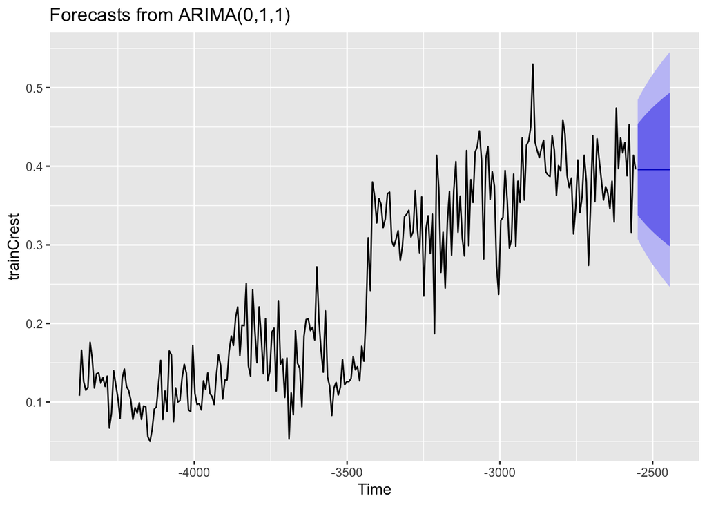

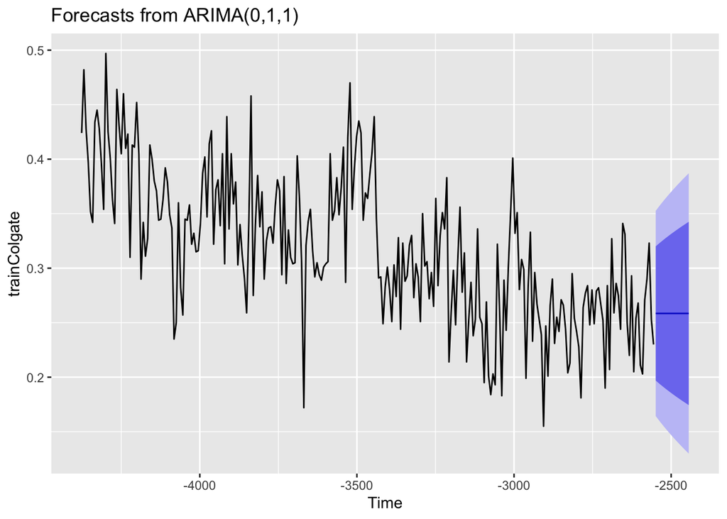

## Modelo ARIMAX

La función de transferencia inicial es de orden 15 para el numerador. Y a partir de ella obtenemos un gráfico de los 15 retardos.

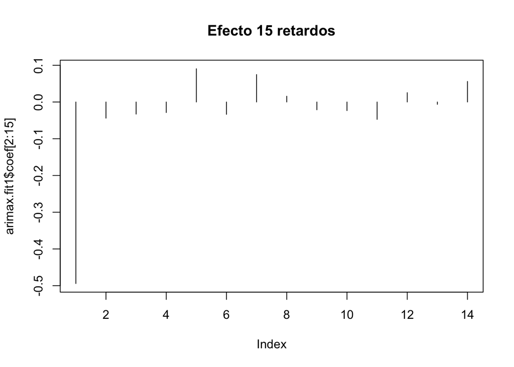

Con el gráfico del efecto de los 15 retardos se visualiza, que la función de transferenia corresponde a un ajuste de (NA,NA,0,0,NA) cuyo summary sería el siguiente:

```
##
## Call:
## arimax(x = dColgate134, order = c(0, 1, 1), include.mean = TRUE, fixed = c(NA,
##     NA, 0, 0, NA), method = "ML", xtransf = dCrest134, transfer = list(c(1,
##     2)))
##
## Coefficients:
##           ma1  Marketshare-AR1  Marketshare-MA0  Marketshare-MA1
##       -0.9999           0.2459                0                0
## s.e.   0.0096           2.9924                0                0
##       Marketshare-MA2
##               -0.0206
## s.e.           0.1787
##
## sigma^2 estimated as 0.003445:  log likelihood = 361.28,  aic = -716.56
```

El modelo tiene un AIC de -716.56. El impacto de Crest sobre colgate es negativo según sus coeficientes.